# notebook

## 1. Meet Dr. Ignaz Semmelweis

[figure not shown]

This is Dr. Ignaz Semmelweis, a Hungarian physician born in 1818 and active at the Vienna General Hospital. If Dr. Semmelweis looks troubled it's probably because he's thinking about *childbed fever*: A deadly disease affecting women that just have given birth. He is thinking about it because in the early 1840s at the Vienna General Hospital as many as 10% of the women giving birth die from it. He is thinking about it because he knows the cause of childbed fever: It's the contaminated hands of the doctors delivering the babies. And they won't listen to him and *wash their hands*!

In this notebook, we're going to reanalyze the data that made Semmelweis discover the importance of *handwashing*. Let's start by looking at the data that made Semmelweis realize that something was wrong with the procedures at Vienna General Hospital.

```r
# Load in the tidyverse package
# .... YOUR CODE FOR TASK 1 ....
library(tidyverse)
# Read datasets/yearly_deaths_by_clinic.csv into yearly
yearly <- read_csv('datasets/yearly_deaths_by_clinic.csv')

# Print out yearly
# .... YOUR CODE FOR TASK 1 ....
yearly
```

| year | births | deaths | clinic |
| --- | --- | --- | --- |
| 1841 | 3036 | 237 | clinic 1 |
| 1842 | 3287 | 518 | clinic 1 |
| 1843 | 3060 | 274 | clinic 1 |
| 1844 | 3157 | 260 | clinic 1 |
| 1845 | 3492 | 241 | clinic 1 |
| 1846 | 4010 | 459 | clinic 1 |
| 1841 | 2442 | 86 | clinic 2 |
| 1842 | 2659 | 202 | clinic 2 |
| 1843 | 2739 | 164 | clinic 2 |
| 1844 | 2956 | 68 | clinic 2 |
| 1845 | 3241 | 66 | clinic 2 |
| 1846 | 3754 | 105 | clinic 2 |

```r
library(testthat)
library(IRkernel.testthat)
run_tests({
    test_that("Read in data correctly.", {
        expect_is(yearly, "tbl_df",
            info = 'You should use read_csv (with an underscore) to read "datasets/yearly_deaths_by_clinic.csv" into yearly.')
    })

    test_that("Read in data correctly.", {
        yearly_temp <- read_csv('datasets/yearly_deaths_by_clinic.csv')
        expect_equivalent(yearly, yearly_temp,
            info = 'yearly should contain the data in "datasets/yearly_deaths_by_clinic.csv"')
    })
})
```

[output not shown]

## 2. The alarming number of deaths

The table above shows the number of women giving birth at the two clinics at the Vienna General Hospital for the years 1841 to 1846. You'll notice that giving birth was very dangerous; an *alarming* number of women died as the result of childbirth, most of them from childbed fever.

We see this more clearly if we look at the *proportion of deaths* out of the number of women giving birth.

```r
# Adding a new column to yearly with proportion of deaths per no. births
# .... YOUR CODE FOR TASK 1 ....
proportion_deaths <- yearly$deaths/yearly$births
yearly <-mutate(yearly,proportion_deaths)
# Print out yearly
yearly
```

| year | births | deaths | clinic | proportion_deaths |
| --- | --- | --- | --- | --- |
| 1841 | 3036 | 237 | clinic 1 | 0.07806324 |
| 1842 | 3287 | 518 | clinic 1 | 0.15759051 |
| 1843 | 3060 | 274 | clinic 1 | 0.08954248 |
| 1844 | 3157 | 260 | clinic 1 | 0.08235667 |
| 1845 | 3492 | 241 | clinic 1 | 0.06901489 |
| 1846 | 4010 | 459 | clinic 1 | 0.11446384 |
| 1841 | 2442 | 86 | clinic 2 | 0.03521704 |
| 1842 | 2659 | 202 | clinic 2 | 0.07596841 |
| 1843 | 2739 | 164 | clinic 2 | 0.05987587 |
| 1844 | 2956 | 68 | clinic 2 | 0.02300406 |
| 1845 | 3241 | 66 | clinic 2 | 0.02036409 |
| 1846 | 3754 | 105 | clinic 2 | 0.02797017 |

```r
run_tests({
    test_that("A proportion_deaths column exists", {
        expect_true("proportion_deaths" %in% names(yearly),
            info = 'yearly should have the new column proportion_deaths')
    })

    test_that("Read in data correctly.", {
        yearly_temp <- read_csv('datasets/yearly_deaths_by_clinic.csv') %>%
          mutate(proportion_deaths = deaths / births)
        expect_equivalent(yearly, yearly_temp,
            info = 'proportion_deaths should be calculated as deaths / births')
    })
})
```

[output not shown]

## 3. Death at the clinics

If we now plot the proportion of deaths at both clinic 1 and clinic 2 we'll see a curious pattern...

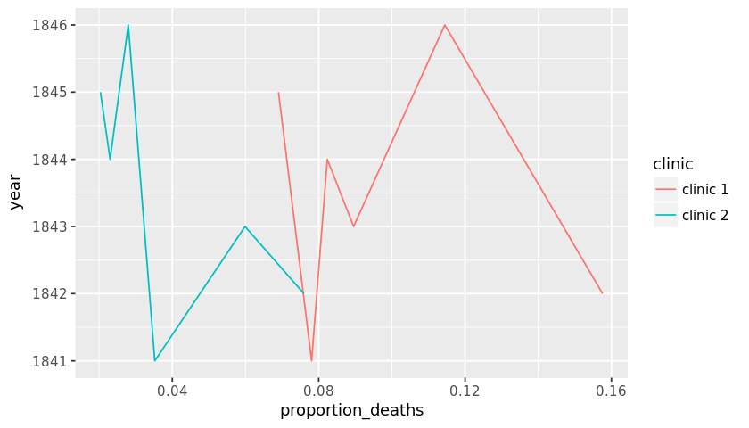

```r
# Setting the size of plots in this notebook
options(repr.plot.width=7, repr.plot.height=4)

# Plot yearly proportion of deaths at the two clinics
# .... YOUR CODE FOR TASK 3 ....
ggplot(yearly,aes(proportion_deaths,year)) + geom_line(aes(group = clinic ,color = clinic))
```

```r
run_tests({
    test_that("The right columns are plotted", {
        correct_mapping <- c("x", "y", "colour")
        student_mapping <- names(last_plot()$labels)
        student_mapping <- student_mapping[student_mapping %in% c("x", "y", "colour")]
        expect_equivalent(correct_mapping, student_mapping,
            info = 'year should be on the x-axis, proportion_deaths on the y-axis, and the color should depend on clinic .')
    })

})
```

[output not shown]

## 4. The handwashing begins

Why is the proportion of deaths constantly so much higher in Clinic 1? Semmelweis saw the same pattern and was puzzled and distressed. The only difference between the clinics was that many medical students served at Clinic 1, while mostly midwife students served at Clinic 2. While the midwives only tended to the women giving birth, the medical students also spent time in the autopsy rooms examining corpses.

Semmelweis started to suspect that something on the corpses, spread from the hands of the medical students, caused childbed fever. So in a desperate attempt to stop the high mortality rates, he decreed: *Wash your hands!* This was an unorthodox and controversial request, nobody in Vienna knew about bacteria at this point in time.

Let's load in monthly data from Clinic 1 to see if the handwashing had any effect.

```r
# Read datasets/monthly_deaths.csv into monthly
monthly <- read_csv('datasets/monthly_deaths.csv')

# Adding a new column with proportion of deaths per no. births
# .... YOUR CODE FOR TASK 4 ....
monthly <- mutate(monthly,proportion_deaths = (monthly$deaths/monthly$births))
# Print out the first rows in monthly
# .... YOUR CODE FOR TASK 4 ....
head(monthly)
```

| date | births | deaths | proportion_deaths |
| --- | --- | --- | --- |
| 1841-01-01 | 254 | 37 | 0.145669291 |
| 1841-02-01 | 239 | 18 | 0.075313808 |
| 1841-03-01 | 277 | 12 | 0.043321300 |
| 1841-04-01 | 255 | 4 | 0.015686275 |
| 1841-05-01 | 255 | 2 | 0.007843137 |
| 1841-06-01 | 200 | 10 | 0.050000000 |

```r
run_tests({

   test_that("Read in data correctly.", {
        expect_is(monthly, "tbl_df",
            info = 'You should use read_csv (with an underscore) to read "datasets/monthly_deaths.csv" into monthly.')
    })

    test_that("Read in monthly correctly.", {
        monthly_temp <- read_csv("datasets/monthly_deaths.csv")
        expect_true(all(names(monthly_temp) %in% names(monthly)),
            info = 'monthly should contain the data in "datasets/monthly_deaths.csv"')
    })

    test_that("proportion_death is calculated correctly.", {
        monthly_temp <- read_csv("datasets/monthly_deaths.csv")
        monthly_temp <- monthly_temp %>%
          mutate(proportion_deaths = deaths / births)
        expect_equivalent(monthly, monthly_temp,
            info = 'proportion_deaths should be calculated as deaths / births')
    })
})
```

[output not shown]

## 5. The effect of handwashing

With the data loaded we can now look at the proportion of deaths over time. In the plot below we haven't marked where obligatory handwashing started, but it reduced the proportion of deaths to such a degree that you should be able to spot it!

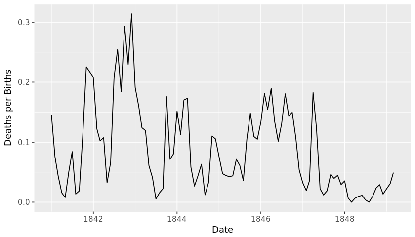

```r
# Plot monthly proportion of deaths
# ... YOUR CODE FOR TASK 5 ...
ggplot(monthly,aes(date,proportion_deaths)) + geom_line() + labs(y ='Deaths per Births',x='Date')
```

```r
run_tests({
    test_that("The right columns are plotted", {
        correct_mapping <- list(x = as.symbol("date"), y = as.symbol("proportion_deaths"))
        student_mapping <- last_plot()$mapping
        expect_equivalent(correct_mapping, student_mapping,
            info = 'date should be on the x-axis, proportion_deaths on the y-axis.')
    })
})
```

[output not shown]

## 6. The effect of handwashing highlighted

Starting from the summer of 1847 the proportion of deaths is drastically reduced and, yes, this was when Semmelweis made handwashing obligatory.

The effect of handwashing is made even more clear if we highlight this in the graph.

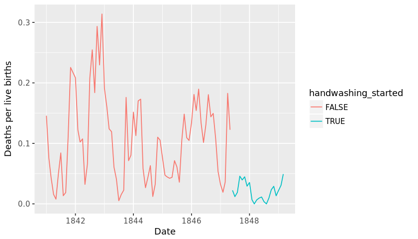

```r
# From this date handwashing was made mandatory
handwashing_start = as.Date('1847-06-01')

# Add a TRUE/FALSE column to monthly called handwashing_started
# .... YOUR CODE FOR TASK 6 ....
monthly <- mutate(monthly,handwashing_started = (handwashing_start <= monthly$date))
# Plot monthly proportion of deaths before and after handwashing
# .... YOUR CODE FOR TASK 6 ....
ggplot(monthly,aes(date,proportion_deaths)) + geom_line(aes(group = handwashing_started,color = handwashing_started)) + labs(x = "Date",y="Deaths per live births")
```

```r
run_tests({
    test_that("handwashing_started has been defined", {
        expect_true("handwashing_started" %in% names(monthly),
            info = 'monthly should contain the column handwashing_started.')
    })

    test_that("there are 22 rows where handwashing_started is TRUE", {
        expect_equal(22, sum(monthly$handwashing_started),
            info = 'handwashing_started should be a TRUE/FALSE column where the rows where handwashing was enforced are set to TRUE.')
    })

    test_that("The right columns are plotted", {
        correct_mapping <- c("x", "y", "colour")
        student_mapping <- names(last_plot()$labels)
        student_mapping <- student_mapping[student_mapping %in% c("x", "y", "colour")]
        expect_equivalent(correct_mapping, student_mapping,
            info = 'date should be on the x-axis, proportion_deaths on the y-axis, and handwashing_started should be mapped to color.')
    })
})
```

[output not shown]

## 7. More handwashing, fewer deaths?

Again, the graph shows that handwashing had a huge effect. How much did it reduce the monthly proportion of deaths on average?

```r
# Calculating the mean proportion of deaths
# before and after handwashing.

monthly_summary <- monthly %>% group_by(handwashing_started) %>% summarise(mean(proportion_deaths))
# .... YOUR CODE FOR TASK 7 HERE ....

# Printing out the summary.
monthly_summary
```

| handwashing_started | mean(proportion_deaths) |
| --- | --- |
| FALSE | 0.10504998 |
| TRUE | 0.02109338 |

```r
run_tests({
    test_that("mean_proportion_deaths was calculated correctly", {
        flat_summary <- as.numeric(unlist(monthly_summary))
        handwashing_start = as.Date('1847-06-01')
        monthly_temp <- read_csv("datasets/monthly_deaths.csv") %>%
          mutate(proportion_deaths = deaths / births) %>%
          mutate(handwashing_started = date >= handwashing_start) %>%
          group_by(handwashing_started) %>%
          summarise(mean_proportion_deaths = mean(proportion_deaths))
        expect_true(all(monthly_temp$mean_proportion_deaths %in% flat_summary),
            info = 'monthly_summary should containt the mean monthly proportion of deaths before and after handwashing was enforced.')
    })
})
```

[output not shown]

## 8. A statistical analysis of Semmelweis handwashing data

It reduced the proportion of deaths by around 8 percentage points! From 10% on average before handwashing to just 2% when handwashing was enforced (which is still a high number by modern standards). To get a feeling for the uncertainty around how much handwashing reduces mortalities we could look at a confidence interval (here calculated using a t-test).

```r
# Calculating a 95% Confidence intrerval using t.test
test_result <- t.test(proportion_deaths ~ handwashing_started, data = monthly)
test_result
```

```
	Welch Two Sample t-test

data:  proportion_deaths by handwashing_started
t = 9.6101, df = 92.435, p-value = 1.445e-15
alternative hypothesis: true difference in means is not equal to 0
95 percent confidence interval:
 0.06660662 0.10130659
sample estimates:
mean in group FALSE  mean in group TRUE
         0.10504998          0.02109338
```

```r
run_tests({
    test_that("the confidence intervals match", {
        temp_test_result <- t.test( proportion_deaths ~ handwashing_started, data = monthly)
        expect_equivalent(test_result$conf.int, temp_test_result$conf.int,
            info = 'The t-test should be calculated with proportion_deaths as a function of handwashing_started.')
    })
})
```

[output not shown]

## 9. The fate of Dr. Semmelweis

That the doctors didn't wash their hands increased the proportion of deaths by between 6.7 and 10 percentage points, according to a 95% confidence interval. All in all, it would seem that Semmelweis had solid evidence that handwashing was a simple but highly effective procedure that could save many lives.

The tragedy is that, despite the evidence, Semmelweis' theory — that childbed fever was caused by some "substance" (what we today know as *bacteria*) from autopsy room corpses — was ridiculed by contemporary scientists. The medical community largely rejected his discovery and in 1849 he was forced to leave the Vienna General Hospital for good.

One reason for this was that statistics and statistical arguments were uncommon in medical science in the 1800s. Semmelweis only published his data as long tables of raw data, but he didn't show any graphs nor confidence intervals. If he would have had access to the analysis we've just put together he might have been more successful in getting the Viennese doctors to wash their hands.

```r
# The data Semmelweis collected points to that:
doctors_should_wash_their_hands <- TRUE
```

```r
run_tests({
    test_that("The project is finished.", {
        expect_true(doctors_should_wash_their_hands,
            info = "Semmelweis would argue that doctors_should_wash_their_hands should be TRUE .")
    })
})
```

[output not shown]